```r
library(car)  #for Anova function
```

# Logistic Regression

##### Review of Normal Linear Regression

$$\large Y_i = \beta_0 + \beta_1x_{i1} + ... + \beta_px_{ip} + \epsilon_i$$

$$where \: \epsilon_i \: for \: i = 1,...n \: are \: independent \:$$

$\beta_0,….,\beta_p$ are regression parameters

since $E(\epsilon_i) = 0$ :

$$\large E(Y_i) = \beta_0 + \beta_1x_{i1} + ... + \beta_px_{ip}$$

MLE:

$$\large L(\pi_1,...,\pi_n|y_1,...,y_n) = P(Y_1 = y_1) \times ... \times
P(Y_n = y_n)$$

$$\large =\prod_{i=1}^nP(Y_i = y_i)$$

$$\large = \prod_{i = 1}^n \pi_i^{y_i} (1-\pi_i)^(1-y_i)$$

But this would only give us $\hat{\pi}_i = 0 \: or\: 1$ so it’s pretty much useless

Instead we use the logistic regression model:

## Logistic Regression Formula

$$\large \pi_i = \frac{exp(\beta_0 + \beta_1x_{i1} + ... +
\beta_px_{ip}}{1 + exp(\beta_0 + B_1x_{i1}+...+ \beta_px_{ip}}$$

Or, after some algebra… we call this the ${logit \: transformation}$:

$$\large log(\frac{\pi_i}{1-\pi_i}) = \beta_0 + \beta_1x_{i1} + ... +
\beta_px_{ip}$$

Notice that the LHS is the natural logarithm of the odds of success.

Need to use iteratively reweighted least squares (IRLS) to find the parameter estimates. Basically, the weights are shifted over and over until the likelihood converges to its maximum value. To do so, we use R’s glm() function and optim() function. Implementation shown later.

## Plot of logistic regression model

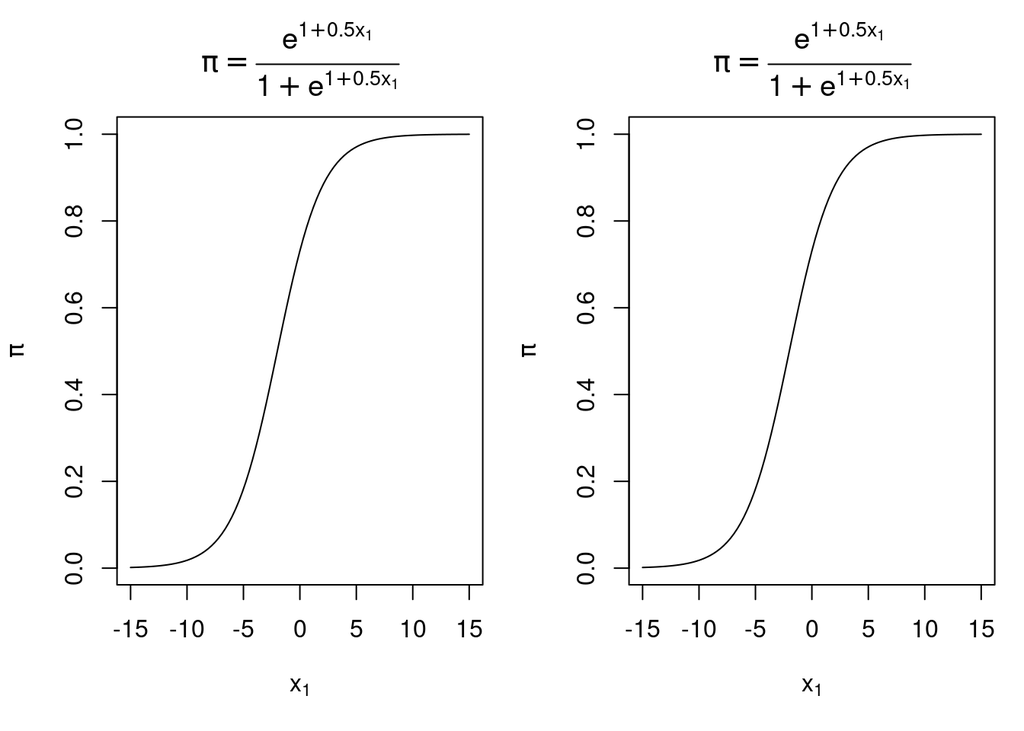

```r
par(mfrow = c(1, 2), mar = c(5, 4, 4, 1))  #prepare plot with 1 row 2 columns 'makeframebyrow', mar parameter is to set margins of bottom, left, top, right. Needed to use it cuz it was cutting off my title and graphs
beta0 <- 1
beta1 <- 0.5

curve(expr = exp(beta0 + beta1 * x)/(1 + exp(beta0 + beta1 *
    x)), xlim = c(-15, 15), col = "black", main = expression(pi ==
    frac(e^{
        1 + 0.5 * x[1]
    }, 1 + e^{
        1 + 0.5 * x[1]
    })), xlab = expression(x[1]), ylab = expression(pi))

beta <- -0.5
curve(expr = exp(beta0 + beta1 * x)/(1 + exp(beta0 + beta1 *
    x)), xlim = c(-15, 15), col = "black", main = expression(pi ==
    frac(e^{
        1 + 0.5 * x[1]
    }, 1 + e^{
        1 + 0.5 * x[1]
    })), xlab = expression(x[1]), ylab = expression(pi))
```

## Example of Logistic Regression

Data consisting of a bunch of independent field kicks in football. The “good” variable is our target variable that we want to estimate. 1 = successful field kick, 0 = failed field kick.

```r
placekick <- read.table(file = "./Placekick.csv", header = TRUE,
    sep = ",")
head(placekick)
```

```
##   week distance change  elap30 PAT type field wind good
## 1    1       21      1 24.7167   0    1     1    0    1
## 2    1       21      0 15.8500   0    1     1    0    1
## 3    1       20      0  0.4500   1    1     1    0    1
## 4    1       28      0 13.5500   0    1     1    0    1
## 5    1       20      0 21.8667   1    0     0    0    1
## 6    1       25      0 17.6833   0    0     0    0    1
```

We’re only going to focus on using one variable for now, “distance”, which is how far the kicker was from the field goal.

Thus:
$$logit(\pi) = \beta_0 + \beta_1x_1$$

where x1 = distance

```r
mod.fit <- glm(formula = good ~ distance, family = binomial(link = logit),
    data = placekick)  #glm = generalized linear model
mod.fit$coefficients
```

```
## (Intercept)    distance
##   5.8120798  -0.1150267
```

```r
# more detailed summary of mod.fit
summary(mod.fit)
```

```
##
## Call:
## glm(formula = good ~ distance, family = binomial(link = logit),
##     data = placekick)
##
## Deviance Residuals:
##     Min       1Q   Median       3Q      Max
## -2.7441   0.2425   0.2425   0.3801   1.6092
##
## Coefficients:
##              Estimate Std. Error z value Pr(>|z|)
## (Intercept)  5.812080   0.326277   17.81   <2e-16 ***
## distance    -0.115027   0.008339  -13.79   <2e-16 ***
## ---
## Signif. codes:  0 '***' 0.001 '**' 0.01 '*' 0.05 '.' 0.1 ' ' 1
##
## (Dispersion parameter for binomial family taken to be 1)
##
##     Null deviance: 1013.43  on 1424  degrees of freedom
## Residual deviance:  775.75  on 1423  degrees of freedom
## AIC: 779.75
##
## Number of Fisher Scoring iterations: 6
```

```r
# The last line of this outputing # of fisher scoring
# iterations tells us how many iterations it took for the
# logit function to reach convergence. In this case, it
# took 6 iterations
```

## Example of Logistic Regression W/ 2 Explanatory Variables

#### Using glm()

```r
mod.fit2 <- glm(formula = good ~ change + distance, family = binomial(link = logit),
    data = placekick)
mod.fit2$coefficients
```

```
## (Intercept)      change    distance
##   5.8931814  -0.4477832  -0.1128888
```

In equation form, mod.fit2 is:

$$\large logit(\hat{\pi}) = 5.8932 - 0.4478change - 0.1129 distance$$

```r
vcov(mod.fit2)  #covariance matrix. different from the hessian matrix
```

```
##              (Intercept)        change      distance
## (Intercept)  0.111011379 -0.0094878323 -2.625598e-03
## change      -0.009487832  0.0375091687 -1.311512e-04
## distance    -0.002625598 -0.0001311512  7.129494e-05
```

```r
# to get this covariance matrix, you first get the hessian
# matrix, log it and take the inverse and multiply by -1
```

Example of obtaining the estimated covariance matrix for the regression parameter estimates:

```r
round(summary(mod.fit)$coefficients, 4)
```

```
##             Estimate Std. Error  z value Pr(>|z|)
## (Intercept)   5.8121     0.3263  17.8133        0
## distance     -0.1150     0.0083 -13.7937        0
```

```r
vcov(mod.fit)  #covariance matrix
```

```
##             (Intercept)      distance
## (Intercept)  0.10645675 -2.606250e-03
## distance    -0.00260625  6.953996e-05
```

```r
vcov(mod.fit)[2, 2]  #var-hat(beta-hat_1)
```

```
## [1] 6.953996e-05
```

```r
summary(mod.fit)$coefficients[2, 2]^2  #same as the line above because we're squaring the std.error, which is variance
```

```
## [1] 6.953996e-05
```

Actual matrix calculation of covariance matrix using $(X'VX)^-1$

```r
pi.hat <- mod.fit$fitted.values
V <- diag(pi.hat * (1 - pi.hat))  #getting only diagonal of hte matrix
X <- cbind(1, placekick$distance)
solve(t(X) %*% V %*% X)  # t() is to find transpose %*% for matrix multiplication, solve for inverse
```

```
##             [,1]          [,2]
## [1,]  0.10645678 -2.606250e-03
## [2,] -0.00260625  6.953997e-05
```

```r
# this returns the same thing as the vcov function
```

#### Using likelihood function

We can use both glm() and log-likelihood function to fit our model. Log-likelihood is a more general approach that will be useful later. Here’s an example of how to use the log-likelihood function instead of the glm() to estimate a logistic regression model:

```r
# setting up the function
logL <- function(beta, x, Y) {
    pi <- exp(beta[1] + beta[2] * x)/(1 + exp(beta[1] + beta[2] *
        x))  #pi for logistic regression
    sum(Y * log(pi) + (1 - Y) * log(1 - pi))
}

logL(beta = mod.fit$coefficients, x = placekick$distance, Y = placekick$good)
```

```
## [1] -387.8725
```

```r
logLik(mod.fit)  #Automatic extraction of MLE, good to see that it matches up with our prior glm() function that produced our original mod.fit
```

```
## 'log Lik.' -387.8725 (df=2)
```

Now to optimize our estimates with optim():

```r
# Find the starting values for parameter estimates
reg.mod <- lm(formula = good ~ distance, data = placekick)
reg.mod$coefficients
```

```
## (Intercept)    distance
##  1.25202444 -0.01330212
```

```r
mod.fit.optim <- optim(par = reg.mod$coefficients, fn = logL,
    hessian = TRUE, x = placekick$distance, Y = placekick$good,
    control = list(fnscale = -1), method = "BFGS")
# since we want to maximize logL, we have control =
# list(fnscale = -1) which tells the function to minimize
# the negative of logL. optim() default is to minimize a
# function so we need to do this

names(mod.fit.optim)
```

```
## [1] "par"         "value"       "counts"      "convergence" "message"
## [6] "hessian"
```

```r
mod.fit.optim$par
```

```
## (Intercept)    distance
##   5.8112544  -0.1150046
```

```r
mod.fit.optim$value  #maximum value of the function
```

```
## [1] -387.8725
```

```r
mod.fit.optim$convergence  #0 means convergence was achieved
```

```
## [1] 0
```

```r
-solve(mod.fit.optim$hessian)  #covariance matrix
```

```
##              (Intercept)      distance
## (Intercept)  0.106482867 -2.607258e-03
## distance    -0.002607258  6.957463e-05
```

## Alternative: Logistic Regression w/ Multiple Trials

Let’s say we have $J$ trials each with their own different weights for their explanatory variables. Then the log-likelihood function is:

$$\large log[L(\beta_0,...,\beta_p|w_1,...,w_j)] =
\Sigma_{j=1}^Jlog[({n_j\choose x_j})] + w_jlog(\pi_j) +
(n_j-w_j)log(1-\pi_j)$$

Because $\large {n_j\choose x_j}$ is a constant, the estimated parameter values do not change. So the MLEs are the same for every binary response

Example:

```r
w <- aggregate(x = good ~ distance, data = placekick, FUN = sum)

n <- aggregate(x = good ~ distance, data = placekick, FUN = length)

w.n <- data.frame(distance = w$distance, success = w$good, trials = n$good,
    proportion = round(w$good/n$good, 4))
head(w.n)  #now a binomial variable
```

```
##   distance success trials proportion
## 1       18       2      3     0.6667
## 2       19       7      7     1.0000
## 3       20     776    789     0.9835
## 4       21      19     20     0.9500
## 5       22      12     14     0.8571
## 6       23      26     27     0.9630
```

```r
mod.fit.bin <- glm(formula = success/trials ~ distance, weights = trials,
    family = binomial(link = logit), data = w.n)
summary(mod.fit.bin)
```

```
##
## Call:
## glm(formula = success/trials ~ distance, family = binomial(link = logit),
##     data = w.n, weights = trials)
##
## Deviance Residuals:
##     Min       1Q   Median       3Q      Max
## -2.0373  -0.6449  -0.1424   0.5004   2.2758
##
## Coefficients:
##              Estimate Std. Error z value Pr(>|z|)
## (Intercept)  5.812080   0.326277   17.81   <2e-16 ***
## distance    -0.115027   0.008339  -13.79   <2e-16 ***
## ---
## Signif. codes:  0 '***' 0.001 '**' 0.01 '*' 0.05 '.' 0.1 ' ' 1
##
## (Dispersion parameter for binomial family taken to be 1)
##
##     Null deviance: 282.181  on 42  degrees of freedom
## Residual deviance:  44.499  on 41  degrees of freedom
## AIC: 148.46
##
## Number of Fisher Scoring iterations: 5
```